# Tidybiology Final Project

Junqi Lu

October 21, 2019

## Load libraries, such as tidyverse and tidybiology

## Import data

I mainly worked on the chromosome dataset in the tidybiology package

## Take a `glimpse` into the data in the dataframe

The dataset chromosome has 24 rows (for 24 chromsomes) and 14 variables for different properties of the 24 human chromosomes.

```
## Observations: 24
## Variables: 14
## $ id                     <fct> 1, 2, 3, 4, 5, 6, 7, 8, 9, 10, 11, 12, 13…
## $ length_mm              <dbl> 85, 83, 67, 65, 62, 58, 54, 50, 48, 46, 4…
## $ basepairs              <dbl> 248956422, 242193529, 198295559, 19021455…
## $ variations             <dbl> 12151146, 12945965, 10638715, 10165685, 9…
## $ protein_codinggenes    <int> 2058, 1309, 1078, 752, 876, 1048, 989, 67…
## $ pseudo_genes           <int> 1220, 1023, 763, 727, 721, 801, 885, 613,…
## $ totallongnc_rna        <int> 1200, 1037, 711, 657, 844, 639, 605, 735,…
## $ totalsmallnc_rna       <int> 496, 375, 298, 228, 235, 234, 208, 214, 1…
## $ mi_rna                 <int> 134, 115, 99, 92, 83, 81, 90, 80, 69, 64,…
## $ r_rna                  <int> 66, 40, 29, 24, 25, 26, 24, 28, 19, 32, 2…
## $ sn_rna                 <int> 221, 161, 138, 120, 106, 111, 90, 86, 66,…
## $ sno_rna                <int> 145, 117, 87, 56, 61, 73, 76, 52, 51, 56,…
## $ miscnc_rna             <int> 192, 176, 134, 104, 119, 105, 143, 82, 96…
## $ centromereposition_mbp <dbl> 125.0, 93.3, 91.0, 50.4, 48.4, 61.0, 59.9…
```

## More statistics by `skim` for a general sense of the dataset

```
## Skim summary statistics
##  n obs: 24
##  n variables: 14
##
## ── Variable type:factor ──────────────────────────────────────────────────────────────────────────────────────────────────────────
##  variable missing complete  n n_unique             top_counts ordered
##        id       0       24 24       24 1: 1, 2: 1, 3: 1, 4: 1   FALSE
##
## ── Variable type:integer ─────────────────────────────────────────────────────────────────────────────────────────────────────────
##             variable missing complete  n   mean     sd  p0    p25   p50
##               mi_rna       0       24 24  73.17  32.21  15  55.75  75
##           miscnc_rna       0       24 24  92.21  42.79   8  66.5   94.5
##  protein_codinggenes       0       24 24 849.96 440.28  71 595.75 836
##         pseudo_genes       0       24 24 608.33 256.03 185 445.75 590.5
##                r_rna       0       24 24  22.08  13.09   5  13     23
##               sn_rna       0       24 24  81     47.5   17  49.75  77
##              sno_rna       0       24 24  63.38  34.89   3  36.75  59.5
##      totallongnc_rna       0       24 24 613.62 252.99  71 439    633.5
##     totalsmallnc_rna       0       24 24 208.88  98.51  30 167    220.5
##      p75 p100     hist
##    92     134 ▃▅▃▇▆▆▃▃
##   107.5   192 ▂▂▃▇▃▂▁▂
##  1055.5  2058 ▃▃▆▇▅▁▁▁
##   772.5  1220 ▃▃▇▃▇▂▁▁
##    27.25   66 ▅▇▇▅▁▁▁▁
##   106     221 ▅▇▇▃▂▁▁▁
##    76     145 ▂▇▅▇▃▁▁▂
##   751    1200 ▁▂▇▅▇▅▁▁
##   236     496 ▂▂▃▇▁▁▁▁
##
## ── Variable type:numeric ─────────────────────────────────────────────────────────────────────────────────────────────────────────
##                variable missing complete  n          mean            sd
##               basepairs       0       24 24       1.3e+08       5.8e+07
##  centromereposition_mbp       0       24 24      43.36         28.61
##               length_mm       0       24 24      43.83         19.79
##              variations       0       24 24 6484571.5     3264765.9
##            p0           p25           p50           p75      p100     hist
##       4.7e+07       8.3e+07       1.3e+08       1.6e+08   2.5e+08 ▇▅▅▇▅▅▁▃
##      12.5          18.73         38.4          55.25    125       ▇▃▅▂▁▂▁▁
##      16            27.75         45.5          55        85       ▇▅▅▇▅▅▁▃
##  211643       4395298.5     6172346       8742592.5       1.3e+07 ▁▂▇▃▅▅▂▂
```

## EDA

I began with a correlation analysis of all the factors with each other and it turned out that all of them are positively correlated by a certain degree.

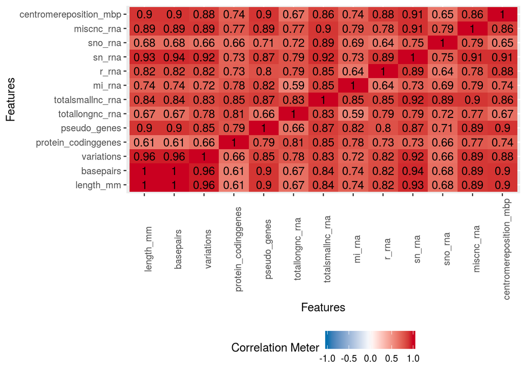

## EDA Graph

Inspired by the new PCB faculty Zhao Zhang ZZ’s research on regulatory gene elements, I want to explore more into the pseudo-genes and their origins. Some people might think that pseudo-genes and protein-coding genes are negatively correlated, but it is actually the opposite. After being standarized by the chromosome lengthes, chromosomes with more protein-coding genes tend to have more pseudo-genes.

```
## Smoothing formula not specified. Using: y ~ x
```

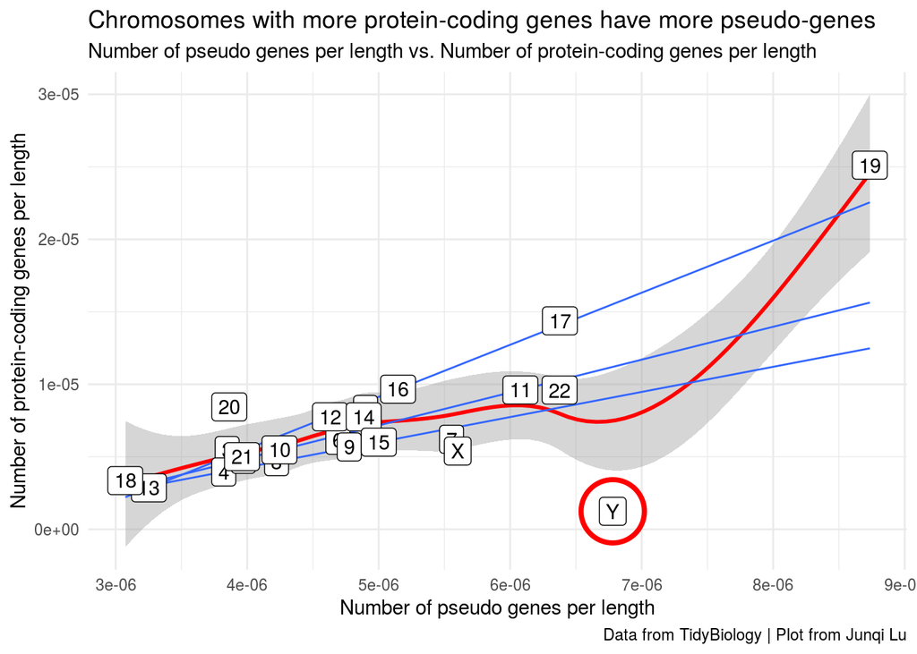

## Final Graph

From the graph above, Y chromosome seems to have a way lower number of protein-coding genes than other chromosomes with similar number of pseudo genes per length. It seems to be an outlier of the trend. Then I made a scatter plot for the pseudo-genes percentage of every chromosome for more comparisons.

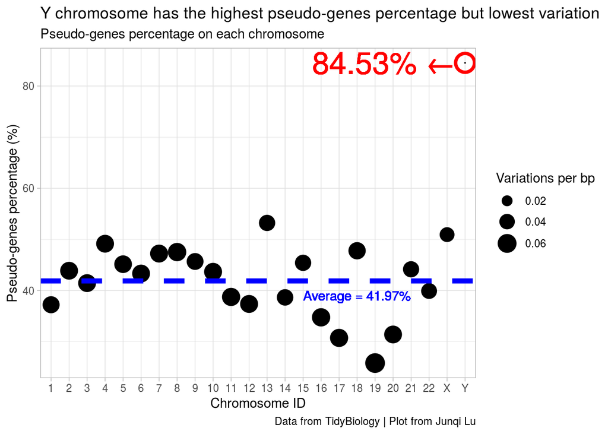

## Conclusions

The Y chromosome has way more pseudo-genes than protein-coding genes when compared to other chromosomes–almost two folds than the average of other chromosomes’ pseudo-genes percentage. However, at the same time, the Y chromosome has the lowest variations per basepair. This indicates those genes on the Y chromosome, mostly pseudo-genes, might play critical regulatory roles and thus remain conservative with pressure over time.

## Prioritized follow-up studies

1. I would like to sequence the Y chromosome from some older human samples to quantify how conservative the Y chromosome’s pseudo-genes are over time.
2. I would also like to classify the pseudo-gene formations of the Y chromosome, whether classical or processed, by investigating the number of non-coding segements, such as introns, on the Y chromosome.

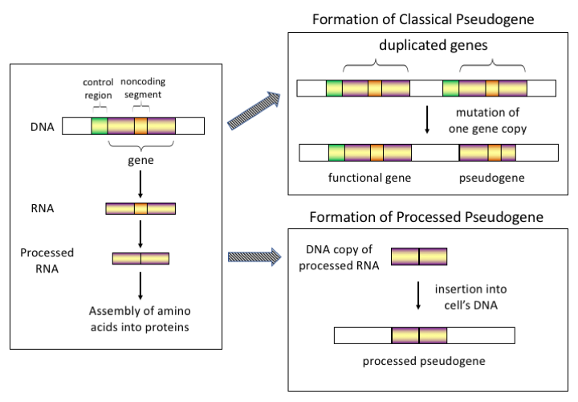

## Acknolwedgements

I want to acknowledge the papers below for the inspiration:

- Plagiarized Errors and Molecular Genetics | National Center for Science Education. (2019). Retrieved 21 October 2019, from https://ncse.ngo/plagiarized-errors-and-molecular-genetics
- Smith, O., Dunshea, G., Sinding, M., Fedorov, S., Germonpre, M., Bocherens, H., & Gilbert, M. (2019). Ancient RNA from Late Pleistocene permafrost and historical canids shows tissue-specific transcriptome survival. PLOS Biology, 17(7), e3000166. doi: 10.1371/journal.pbio.3000166

I also want to thank the creators for the package tidyverse, tidybiology, and DataExplorer, and Dr. Hirschey and TAs, Allie Mills and Akshay Bareja for teaching this class. Thank you all for listening.